# Panel Regression

Natasha Kang

Xiamen University, Chow Institute

May, 2026

## When Cross-Sectional Tools Aren’t Enough

Two cross-sectional levers from earlier:

- **Lect4**: condition on observable confounders.
- **Lect5**: use exogenous variation via instruments.

Both fail when the confounder is *unobserved* **and** no valid instrument exists.

**Canonical example — returns to schooling**: ability is unobserved and correlated with schooling. OLS is biased; no clean instrument is universally available. Need a different route.

## A New Source of Variation

When the same unit is observed at multiple periods, we can compare **the unit to itself**:

- $X_{it}$ takes different values across periods $t$, for fixed unit $i$.
- $Y_{it}$ moves with it.
- Anything *fixed about unit $i$* — observed or not — is held constant **by construction**.

**Payoff**: no instrument needed; no requirement to know what the confounder is.

**Requires**: assumptions on how $X_{it}$ and $\varepsilon_{it}$ co-move *within* unit over time — shapes the rest of the lecture.

## Potential Outcomes

For each unit-period $(i, t)$, the **potential outcome** $Y_{it}(x)$ is the value $Y$ would take if the regressor were set to $x$:

$$Y_{it}(x) \;=\; \text{unit } i\text{'s outcome at time } t \text{ when } X_{it} = x$$

**Notation**:

- Capital $X_{it}$ — the realized random regressor.
- Lowercase $x$ — a hypothetical value.
- $Y_{it} = Y_{it}(X_{it})$ — the observed outcome is the PO evaluated at the realized $X_{it}$.

**Cross-section**: at a single $t$, we see only one PO per unit. Every other value of $x$ is counterfactual — the fundamental problem of causal inference.

**Panel**: across periods, the *same unit* is observed at different realized $X$ values — $Y_{it}(X_{it})$ and $Y_{it'}(X_{it'})$. In a sense, we observe **both potential outcomes** for unit $i$ — just at different times.

## A Linear PO Assumption

Assume the PO function is linear and additively separable:

$$Y_{it}(x) \;=\; \alpha_i \;+\; \lambda_t \;+\; x'\beta \;+\; \varepsilon_{it}$$

- $\alpha_i$ — **unit-fixed term**: every time-invariant feature of individual $i$, observed *or unobserved* (ability, gender, family background, …).
- $\lambda_t$ — **time-fixed term**: every unit-invariant feature of period $t$ (national price level, common macro shock, period-specific common event).
- $\beta$ — the **causal slope** in $x$, common across units and periods.
- $\varepsilon_{it}$ — idiosyncratic disturbance, varying across $i$ and $t$.

## The Empirical Model

Setting $x = X_{it}$ in the linear PO function:

$$Y_{it} \;=\; \alpha_i + \lambda_t + X_{it}'\beta + \varepsilon_{it}$$

$X_{it}$ is **allowed to correlate with** both:

- $\alpha_i$ — unit-level fixed factors.
- $\lambda_t$ — common time shocks.

*In a cross-section, $\alpha_i$ would sit inside the error, requiring $\mathrm{Cov}(X_i, \alpha_i) = 0$.*

## Estimating $\beta$

The parameter we want is $\beta$ — the causal slope. $\alpha_i$ and $\lambda_t$ are unobserved **nuisance terms** in the regression.

**Standard approach — Two-Way Fixed Effects (TWFE)**, via the within transformation:

- Demean $Y, X$ by unit and period means.
- $\alpha_i$ and $\lambda_t$ are eliminated from the regression.
- Leaves an estimating equation in $\beta$ alone.

## The Within Transformation

Take averages of both sides of $Y_{it} = \alpha_i + \lambda_t + X_{it}'\beta + \varepsilon_{it}$:

- **Unit mean**: $\;\;\bar Y_i \;=\; \alpha_i + \bar\lambda + \bar X_i'\beta + \bar\varepsilon_i$
- **Period mean**: $\;\;\bar Y_t \;=\; \bar\alpha + \lambda_t + \bar X_t'\beta + \bar\varepsilon_t$
- **Grand mean**: $\;\;\bar Y \;=\; \bar\alpha + \bar\lambda + \bar X'\beta + \bar\varepsilon$

Combine $\tilde Y_{it} \equiv Y_{it} - \bar Y_i - \bar Y_t + \bar Y$ — $\alpha$ and $\lambda$ terms cancel exactly:

$$\tilde Y_{it} \;=\; \tilde X_{it}'\beta + \tilde\varepsilon_{it}$$

## TWFE Estimator: Formal Derivation

Apply OLS to the double-demeaned model:

$$\hat\beta_{\text{TWFE}} \;=\; \left(\sum_{i,t} \tilde X_{it}\tilde X_{it}'\right)^{-1} \sum_{i,t} \tilde X_{it}\tilde Y_{it}$$

Substitute $\tilde Y_{it} = \tilde X_{it}'\beta + \tilde\varepsilon_{it}$:

$$\hat\beta_{\text{TWFE}} - \beta \;=\; \left(\sum_{i,t} \tilde X_{it}\tilde X_{it}'\right)^{-1} \sum_{i,t} \tilde X_{it}\tilde\varepsilon_{it}$$

Whether $\hat\beta_{\text{TWFE}} \to_p \beta$ depends on the behavior of these two sums. The substantive condition is the identifying assumption — strict exogeneity, next.

## Strict Exogeneity

The identifying assumption for $\beta$:

$$E[\varepsilon_{it} \mid X_{i1}, \dots, X_{iT}, \alpha_i, \lambda_t] = 0$$

The residual $\varepsilon_{it}$ is mean-zero conditional on the entire $X$ trajectory and the FEs.

**Why “strict”?** Unit-demeaning gives

$$\tilde\varepsilon_{it} \;=\; \varepsilon_{it} - \frac{1}{T}\sum_{s=1}^{T}\varepsilon_{is}$$

— a linear combination of errors at every period. So $E[\tilde X_{it}\tilde\varepsilon_{it}] = 0$ requires $E[X_{ir}\varepsilon_{is}] = 0$ at every pair $(r, s)$.

## When Strict Exogeneity Fails

The natural condition $E[\varepsilon_{it} \mid X_{it}, \alpha_i, \lambda_t] = 0$ can hold while strict exogeneity fails — when $X$ at *other* periods correlates with $\varepsilon_{it}$:

- **Lagged dependent variable**: $X_{it} = Y_{i,t-1}$ depends on $\varepsilon_{i,t-1}$ → $\hat\beta_{\text{TWFE}}$ inconsistent (Nickell bias).
- **Feedback / Ashenfelter dip**: treatment adoption $X_{i,t+1}$ responds to past outcomes (and hence past errors).
- **Anticipation**: future $X$ enters today’s $\varepsilon$ via expectations.

## TWFE Estimator: Consistency

Fixed $T$, $N \to \infty$, units i.i.d. The double sum is an average over i.i.d. units:

$$\frac{1}{NT}\sum_{i,t}\tilde X_{it}\tilde X_{it}' \;=\; \frac{1}{N}\sum_i \;\frac{1}{T}\sum_t \tilde X_{it}\tilde X_{it}'$$

LLN applies to the outer sum (over $i$):

- **Rank**: $\frac{1}{NT}\sum_{i,t}\tilde X_{it}\tilde X_{it}' \;\to_p\; Q_{\tilde X \tilde X} \;\equiv\; E\!\left[\frac{1}{T}\sum_t \tilde X_{it}\tilde X_{it}'\right]$, positive definite by assumption.
- **Orthogonality**: $\frac{1}{NT}\sum_{i,t}\tilde X_{it}\tilde\varepsilon_{it} \;\to_p\; E\!\left[\frac{1}{T}\sum_t \tilde X_{it}\tilde\varepsilon_{it}\right] \;=\; 0$ under strict exogeneity.

By Slutsky: $\;\;\hat\beta_{\text{TWFE}} \;\xrightarrow{p}\; \beta$.

## TWFE Estimator: Asymptotic Normality

By a CLT over units (fixed $T$, $N \to \infty$):

$$\sqrt{N}(\hat\beta_{\text{TWFE}} - \beta) \;\xrightarrow{d}\; \mathcal{N}\!\left(0,\; Q_{\tilde X \tilde X}^{-1}\,\Omega\,Q_{\tilde X \tilde X}^{-1}\right)$$

The “meat” of the sandwich:

$$\Omega \;\equiv\; \mathrm{Var}\!\left(\frac{1}{\sqrt N}\sum_{i,t} \tilde X_{it}\tilde\varepsilon_{it}\right) \;=\; E\!\left[\Bigl(\sum_t \tilde X_{it}\tilde\varepsilon_{it}\Bigr)\Bigl(\sum_t \tilde X_{it}\tilde\varepsilon_{it}\Bigr)'\right]$$

(Last equality: i.i.d. across units.) Estimating $\Omega$ correctly is the next slide.

## Decomposing $\Omega$

Recall (Asymptotic Normality slide):

$$\Omega \;=\; E\!\left[\Bigl(\sum_t \tilde X_{it}\tilde\varepsilon_{it}\Bigr)\Bigl(\sum_t \tilde X_{it}\tilde\varepsilon_{it}\Bigr)'\right]$$

Expand the outer sum-product:

$$\Omega \;=\; \underbrace{\sum_{t} E[\tilde\varepsilon_{it}^2\, \tilde X_{it}\tilde X_{it}']}_{\text{same-period (within } (i,t)\text{)}} \;+\; \underbrace{\sum_{t \neq s} E[\tilde\varepsilon_{it}\tilde\varepsilon_{is}\, \tilde X_{it}\tilde X_{is}']}_{\text{cross-period (within unit } i\text{)}}$$

Within a unit, residuals $\tilde\varepsilon_{i,1}, \dots, \tilde\varepsilon_{i,T}$ are typically **serially correlated** — shocks persist over time. The cross-period sum is non-zero.

## Naive vs. Cluster-Robust

**Naive SE** treats $(i,t)$ observations as i.i.d. — sets the cross-period sum to zero, captures only the same-period sum:

$$\hat\Omega_{\text{naive}} \;=\; \frac{1}{NT}\sum_{i,t}\hat\varepsilon_{it}^2\, \tilde X_{it}\tilde X_{it}'$$

Under serial correlation: **underestimates $\Omega$**.

**Cluster-robust** at unit level — keeps both sums:

$$\hat\Omega_{\text{cluster}} \;=\; \frac{1}{N}\sum_i \Bigl(\sum_t \tilde X_{it}\hat\varepsilon_{it}\Bigr)\Bigl(\sum_t \tilde X_{it}\hat\varepsilon_{it}\Bigr)'$$

with $\hat\varepsilon_{it} = \tilde Y_{it} - \tilde X_{it}'\hat\beta_{\text{TWFE}}$.

**Bertrand, Duflo & Mullainathan (2004 QJE)**: in panel-FE/DiD settings, ignoring within-unit correlation causes nominal 5% tests to reject 45%+ of the time.

## Which $X$’s Can TWFE Identify?

TWFE includes $\alpha_i$ and $\lambda_t$. These absorb:

- Anything that’s a **function of $i$ alone** (constant within unit).
- Anything that’s a **function of $t$ alone** (constant within period).

**Implication for the choice of $X$**:

- **Time-invariant within unit** (gender, race, baseline characteristics): absorbed by $\alpha_i$. **Cannot** be identified in TWFE — its coefficient drops out with the FE.
- **Common across units in each period** (national-level policy, macro shock that hits everyone): absorbed by $\lambda_t$. Cannot be identified.
- **Two-way varying** (varies across both $i$ and $t$): identifiable. This is what TWFE *can* estimate.

## Continuous Treatment: Autor-Dorn-Hanson (ADH) China Shock

**Research question** (ADH 2013): Did the rise in **Chinese import competition** between 1990 and 2007 reduce manufacturing employment in U.S. local labor markets exposed to it?

**What is a local labor market?**

- A geographic area where workers can take jobs without relocating.
- The scope where displaced workers search and employers recruit.

**Commuting zones (CZs)** operationalize this:

- Groups of counties merged by commuting flows; ~700 cover the U.S.
- Capture the boundary of where workers actually look for jobs.
- Differ in pre-1990 industrial mix → variation in exposure to Chinese imports.

## ADH: Setup

- **Unit** $c$: commuting zone. **Period** $t$: 1990–2007.
- **Outcome** $L_{ct}$: manufacturing employment share.
- **Treatment** $\text{ChinaShock}_{ct}$: continuous, shift-share construction.

**Shift-share treatment**: sum across industries $j$ of (local share) $\times$ (national shift):

$$\text{ChinaShock}_{ct} \;=\; \sum_{j} \underbrace{\frac{L_{cjt-1}}{L_{ct-1}}}_{\text{share}_{cj}} \cdot \underbrace{\frac{\Delta M_{j,\text{China}\to\text{US},t}}{L_{j,t-1}}}_{\text{shift}_{jt}}$$

- **share**$_{cj}$: industry $j$’s employment share in CZ $c$ at baseline. Varies across CZs; fixed in $t$.
- **shift**$_{jt}$: national change in Chinese imports in industry $j$, per worker. Varies across industries and years; common to all CZs.

## A Pedagogical TWFE Adaptation

We now write down a yearly TWFE specification for the ADH setup:

$$L_{ct} = \alpha_c + \lambda_t + \beta \cdot \text{ChinaShock}_{ct} + \varepsilon_{ct}$$

- $\alpha_c$: CZ fixed effect — absorbs time-invariant CZ characteristics.
- $\lambda_t$: year fixed effect — absorbs national-year shocks common to all CZs.
- $\beta$: average causal effect of one extra unit of import exposure on the manufacturing employment share.

**Honest disclosure**: ADH (2013) does *not* run this yearly TWFE. They use stacked **long-differences** (1990→2000, 2000→2007). The framework below is an adaptation we use to illustrate panel-regression machinery — same identifying logic, different estimation.

## Within-Transformed Treatment

Shorthand: $s_{cj} \equiv \text{share}_{cj}$, $x_{jt} \equiv \text{shift}_{jt}$, $C_{ct} \equiv \text{ChinaShock}_{ct} = \sum_j s_{cj}\, x_{jt}$.

Three means (using $s_{cj}$ fixed in $t$, $x_{jt}$ fixed in $c$):

$$\bar C_c = \sum_j s_{cj}\,\bar x_j, \quad \bar C_t = \sum_j \bar s_j\, x_{jt}, \quad \bar C = \sum_j \bar s_j\,\bar x_j$$

Within transformation:

$$\begin{aligned}
\widetilde C_{ct} \;=\; C_{ct} - \bar C_c - \bar C_t + \bar C
&= \sum_j \big[\,s_{cj}\,x_{jt} - s_{cj}\,\bar x_j - \bar s_j\,x_{jt} + \bar s_j\,\bar x_j\,\big] \\
&= \sum_j (s_{cj} - \bar s_j)(x_{jt} - \bar x_j)
\end{aligned}$$

## What Identifies $\beta$

$$\widetilde C_{ct} \;=\; \sum_j (s_{cj} - \bar s_j)(x_{jt} - \bar x_j)$$

$\widetilde C_{ct}$ is the *idiosyncratic* part of CZ-$c$’s exposure in year $t$ — what’s left after netting out CZ-$c$’s average across years and year-$t$’s average across CZs.

**Where does the variation come from?**

- *Across years*: in year $t$, some industries had unusually large national shifts (large $x_{jt} - \bar x_j$).
- *Across CZs*: CZ $c$ is over-exposed to certain industries relative to the average CZ (large $s_{cj} - \bar s_j$).

By FWL, $\hat\beta$ is the OLS slope of $\widetilde L_{ct}$ on $\widetilde C_{ct}$ across the panel — how much idiosyncratic employment moves per unit of idiosyncratic exposure.

## What Strict Exogeneity Requires

For $\hat\beta$ to be consistent, both pieces of $C_{ct} = \sum_j s_{cj} x_{jt}$ must be uncorrelated with the error:

- **shares** $s_{cj}$ (baseline industry mix) uncorrelated with CZ-year shocks $\varepsilon_{ct}$,
- **shifts** $x_{jt}$ (national industry shocks) uncorrelated with $\varepsilon_{ct}$,

given the FE.

ADH defend each separately:

- **Shares**: measured at $t-1=1990$ — predetermined relative to later $\varepsilon_{ct}$.
- **Shifts**: are they exogenous? $\to$ next slide.

## Are the Shifts Exogenous?

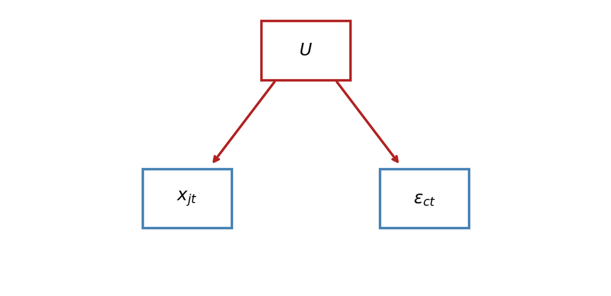

If some unobserved $U$ affects *both* the shifter $x_{jt}$ and the CZ-year shock $\varepsilon_{ct}$, then $x_{jt}$ is correlated with $\varepsilon_{ct}$ — strict exogeneity fails.

**Question**: what could $U$ plausibly be? $\to$ next slide.

## Why the Shifts Aren’t Exogenous

$U$ = **US-side demand shocks**. When industry $j$ weakens domestically (shifting tastes, productivity slowdown, etc.):

- US firms can’t compete $\Rightarrow$ imports fill the gap $\Rightarrow$ raises $x_{jt}$.
- Employment in CZs exposed to industry $j$ falls for non-China reasons $\Rightarrow$ shows up in $\varepsilon_{ct}$.

So $\Delta M_{j,\text{CN}\to\text{US},t}$ confounds Chinese *supply* (what we want — productivity, WTO entry, capacity expansion) with US *demand* (the confounder).

## ADH: The Instrument

**ADH IV**: keep the same shift-share construction, but **replace the shifter** — use Chinese imports to *other* high-income countries instead of US:

$$\text{ChinaShock}^{\text{IV}}_{ct} \;=\; \sum_j s_{cj} \cdot \frac{\Delta M_{j,\text{CN}\to\text{other},t}}{L_{j,t-1}}$$

(8 countries: Australia, Denmark, Finland, Germany, Japan, New Zealand, Spain, Switzerland.)

- **Relevance**: same Chinese supply surge hits all 8 destinations $\Rightarrow$ correlated with the US shifter.
- **Exclusion**: other countries’ imports are not driven by US-specific demand shocks $\Rightarrow$ purges the demand confound.

## ADH: Controls Strengthen Identification

ADH’s preferred specification adds, interacted with the period dummy:

- **Census division** $\times$ period — region-specific time trends.
- **Baseline CZ characteristics** $\times$ period — % college, % female, % manufacturing employment, % foreign-born — measured at a single pre-period baseline.

**Why pre-period?**

- Predetermined: values fixed before the shock arrives.
- Using later values would mix in the *outcome* of treatment — they’d absorb the very effect we want to estimate (“bad controls”).
- Same logic as fixing shares $s_{cj}$ at baseline.

We’ll write these as $W_c^{\text{pre}\prime}\gamma_t$ — interactions of $W^{\text{pre}}$ with period dummies, with a separate coefficient vector per period. Formalized in the next section.

## Why Add $W^{\text{pre}}$ Controls?

- TWFE assumes the time path $\lambda_t$ is **common to all CZs**.
- Strict exogeneity (given $\alpha_c, \lambda_t$) then requires the error to be mean-zero given $X$.

**Problem**: CZs with different baseline characteristics may follow *different* time paths.

- A common $\lambda_t$ is misspecified.
- $\varepsilon_{ct}$ inherits CZ-specific time variation correlated with $X_{ct}$ — strict exogeneity fails.

**Resolution**: let $\lambda_t$ depend on a baseline characteristic $W_c^{\text{pre}}$.

- Stratifies the time path by pre-period composition.
- Relaxes strict exogeneity to a *conditional* version — exogeneity *within strata* of $W^{\text{pre}}$.
- Formalized next.

## General Form: $W^{\text{pre}}$ Interactions

For continuous or multi-dimensional baseline characteristic $W_c^{\text{pre}}$:

$$Y_{ct} \;=\; \alpha_c + \underbrace{\lambda_t + W_c^{\text{pre}\prime}\gamma_t}_{\text{CZ-specific time path}} + X_{ct}'\beta + \varepsilon_{ct}$$

- $\gamma_t \in \mathbb{R}^K$: a *period-specific* coefficient vector on $W^{\text{pre}}$.
- $W_c^{\text{pre}\prime}\gamma_t$ is CZ $c$’s time-$t$ *tilt* away from the common $\lambda_t$ — CZs with different $W^{\text{pre}}$ travel different time paths.

$W_c^{\text{pre}}$ must be **time-invariant** (measured pre-treatment).

- Adding it as a level alone (without time interaction) is absorbed by $\alpha_c$.
- Only the time-varying interaction $W_c^{\text{pre}\prime}\gamma_t$ identifies anything new.

## The Fully Expanded Form

Period dummies and their $W^{\text{pre}}$ interactions written out (observation indexed by $(c, t')$ on this slide; $t$ is the summation index):

$$Y_{c,t'} = \alpha_c \;+\; \sum_{t=2}^{T} \mathbf{1}[t'=t]\,\lambda_{t} \;+\; \sum_{t=2}^{T} \mathbf{1}[t'=t] \cdot W_c^{\text{pre}\prime}\gamma_{t} \;+\; X_{c,t'}'\beta + \varepsilon_{c,t'}$$

**Parameters:**

- $\alpha_c$: $N$ unit FE.
- $\lambda_{t}$ for $t = 2, \ldots, T$: $T-1$ scalar coefficients on period dummies.
- $\gamma_{t}$ for $t = 2, \ldots, T$: each a $K$-vector — $K(T-1)$ coefficients on (period $\times W^{\text{pre}}$) interactions.
- $\beta$: causal slope on $X$.

## Dummy Trap and Reference Period

Why drop one period for both $\lambda$ and $\gamma$?

**Standalone period dummies**: $\sum_{t=1}^{T} \mathbf{1}[t'=t] = 1$ for all $(c, t')$ — the constant is in span($\alpha_c$). Including all $T$ → perfect collinearity. Drop $\lambda_{t_0}$.

**$W^{\text{pre}}$-interaction dummies**: $\sum_{t=1}^{T} \mathbf{1}[t'=t] \cdot W_c^{\text{pre}} = W_c^{\text{pre}}$ — time-invariant, also in span($\alpha_c$). Drop $\gamma_{t_0}$.

**Convention**: drop the *same* reference period $t_0$ — typically the last pre-treatment period. Coefficients $\lambda_{t}, \gamma_{t}$ are then interpreted *relative to* $t_0$.

## ADH: Headline Finding

Pulling everything together — what does ADH actually find?

From their preferred IV spec with $W^{\text{pre}}$ controls (Table 3, col. 6, stacked long-differences):

A $1,000-per-worker increase in import exposure *over a decade* $\Rightarrow$ a **0.596 pp** drop in CZ manufacturing employment / working-age population.

Stability across spec columns 1–6 (with vs. without $W^{\text{pre}}$ controls) is part of ADH’s robustness argument.

## What’s Next: DiD as a Special Case

When treatment is **binary** and **group-structured**:

$$D_{it} = G_i \cdot \mathbf{1}[t \geq t^*]$$

- $G_i \in \{0, 1\}$: indicator that unit $i$ belongs to the *treated group* (treated at some point).
- $t^*$: the period when treatment turns on for the treated group.

TWFE specializes to **difference-in-differences**, the canonical design covered in lect6b.